# Paper: Inequality Belief Systems and Attitude Towards Redistribution in US and the Netherlands

# Variables

| variable | label |
| --- | --- |
| perc_income | Differences in income in the United States are too large |
| perc_wealth | Differences in wealth in the United States are too large |
| perc_poor | Children in poor families do not have the same opportunities for getting ahead a |
| perc_black | Black children do not have the same opportunities for getting ahead as white chi |
| bel_merit | Society is fair when hard-working people earn more than others |
| bel_diversity | Racial diversity makes America stronger |
| bel_equality | For society to be fair, differences in people’s standard of living should be sma |
| ib_weafam | coming from a wealthy family |
| ib_edupar | having highly educated parents |
| ib_edu | having a good education |
| ib_work | hard work |
| ib_people | knowing the right people |
| ib_race | race or skin color |
| ib_migra | legal or immigration status |
| ib_relig | religion |
| ib_sex | being born a man or woman |
| att_redist | It is the responsibility of the government to reduce the differences in income b |

## Descriptives

### US

```
##
## ==================================================
## Statistic         N     Mean    St. Dev. Min  Max
## --------------------------------------------------
## nomem_encr      2,479 1,252.175 722.849   1  2,505
## survey          2,479   1.401    0.490    1    2
## country         2,479   1.000    0.000    1    1
## treatment       2,479   2.201    1.169    1    4
## age             2,479  43.538    16.174  18   84
## agegroups       2,479   3.050    1.502    1    5
## education       2,479   2.583    0.682    1    3
## working         2,479   0.650    0.477    0    1
## politics        2,479   3.873    2.938    0   10
## pol5            2,479   2.522    1.238    1    5
## hhincome        2,479   6.331    3.243    1   11
## assets          2,479   3.140    1.909    0    7
## immigrant       2,479   0.075    0.263    0    1
## marital         2,479   0.472    0.499    0    1
## ladder_present  2,479   4.153    1.112    1    7
## perc_income     2,479   5.731    1.403    1    7
## perc_wealth     2,479   5.889    1.420    1    7
## perc_poor       2,479   5.971    1.364    1    7
## perc_black      2,479   5.322    1.701    1    7
## bel_merit       2,479   4.922    1.392    1    7
## bel_diversity   2,479   5.741    1.457    1    7
## bel_equality    2,479   4.885    1.576    1    7
## ib_weafam       2,479   3.509    0.979    1    5
## ib_edupar       2,479   3.411    0.931    1    5
## ib_edu          2,479   4.052    0.790    1    5
## ib_work         2,479   4.048    0.954    1    5
## ib_people       2,479   3.857    0.925    1    5
## ib_race         2,479   2.904    1.179    1    5
## ib_migra        2,479   3.567    1.070    1    5
## ib_relig        2,479   2.001    1.030    1    5
## ib_sex          2,479   2.714    1.163    1    5
## att_redist      2,479   4.950    1.844    1    7
## att_discrim     2,479   5.696    1.553    1    7
## hhincome_groups 2,479   2.200    0.651    1    3
## CCA             2,479   0.472    0.499    0    1
## --------------------------------------------------
```

### NL

```
##
## ============================================================
## Statistic         N      Mean      St. Dev.    Min     Max
## ------------------------------------------------------------
## nomem_encr      1,452 848,800.600 29,034.480 800,057 899,794
## survey          1,452    1.000      0.000       1       1
## country         1,452    2.000      0.000       2       2
## treatment       1,452    2.003      0.818       1       3
## age             1,452   57.738      16.816     18      92
## agegroups       1,452    4.081      1.282       1       5
## education       1,452    2.337      0.883       1       3
## working         1,452    0.429      0.495       0       1
## politics        1,452    5.202      2.095       0      10
## pol5            1,452    3.060      0.867       1       5
## hhincome        1,452    5.120      2.388       1       9
## assets          1,452    3.388      1.402       0       7
## immigrant       1,452    0.079      0.270       0       1
## marital         1,452    0.567      0.496       0       1
## ladder_present  1,452    4.867      1.031       1       7
## perc_income     1,452    5.021      1.405       1       7
## perc_wealth     1,452    5.187      1.396       1       7
## perc_poor       1,452    5.242      1.343       1       7
## perc_black      1,452    4.634      1.493       1       7
## bel_merit       1,452    3.382      1.596       1       7
## bel_diversity   1,452    3.667      1.574       1       7
## bel_equality    1,452    4.379      1.491       1       7
## ib_weafam       1,452    2.856      0.862       1       5
## ib_edupar       1,452    3.163      0.763       1       5
## ib_edu          1,452    3.696      0.713       1       5
## ib_work         1,452    3.691      0.783       1       5
## ib_people       1,452    3.488      0.760       1       5
## ib_race         1,452    2.491      0.953       1       5
## ib_migra        1,452    2.600      0.925       1       5
## ib_relig        1,452    1.833      0.752       1       5
## ib_sex          1,452    2.193      0.884       1       5
## att_redist      1,452    5.039      1.457       1       7
## att_discrim     1,452    5.681      1.242       1       7
## hhincome_groups 1,452    1.724      0.545       1       3
## CCA             1,452    0.477      0.500       0       1
## ------------------------------------------------------------
```

# Inequality Belief Systems

## Distribution

### US

```
## CCA <numeric>
## # total N=2479 valid N=2479 mean=0.47 sd=0.50
##
## Value |    N | Raw % | Valid % | Cum. %
## ---------------------------------------
##     0 | 1310 | 52.84 |   52.84 |  52.84
##     1 | 1169 | 47.16 |   47.16 | 100.00
##  <NA> |    0 |  0.00 |    <NA> |   <NA>
```

### NL

```
## CCA <numeric>
## # total N=1452 valid N=1452 mean=0.48 sd=0.50
##
## Value |   N | Raw % | Valid % | Cum. %
## --------------------------------------
##     0 | 759 | 52.27 |   52.27 |  52.27
##     1 | 693 | 47.73 |   47.73 | 100.00
##  <NA> |   0 |  0.00 |    <NA> |   <NA>
```

## EGA

### US

#### Group 0

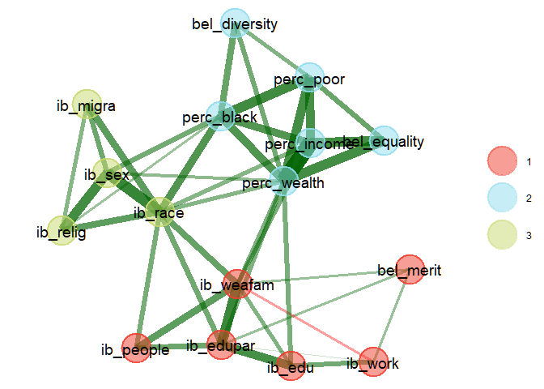

#### Group 1

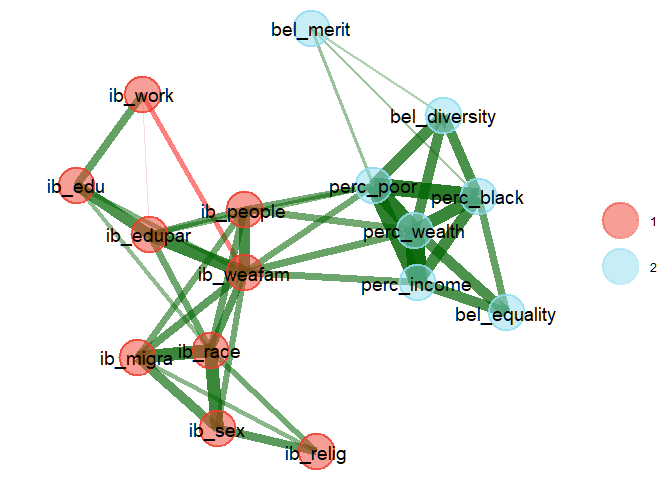

### NL

#### Group 0

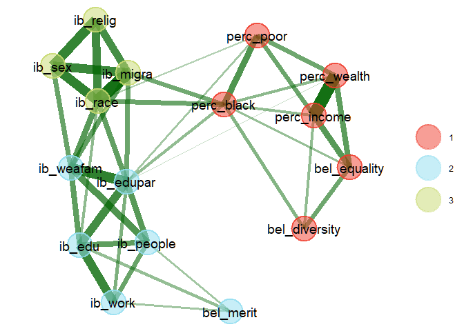

#### Group 1

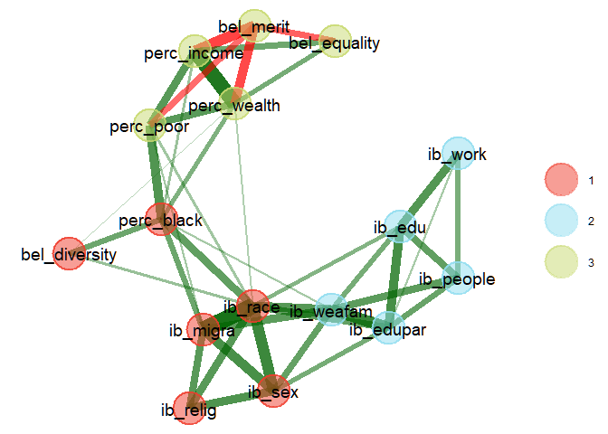

# Sociodemographic Determinants of Inequality Belief Systems

## Regressions

Table. Logistic regression models on the probability to be a member of the CCA group 1 (CCA) - US & NL

M1_US

M2_US

M3_US

M1_NL

M2_NL

M3_NL

Odds Ratios

Odds Ratios

Odds Ratios

Odds Ratios

Odds Ratios

Odds Ratios

(Intercept)

1.16 *  
(0.99 – 1.35)

2.74 ***  
(1.71 – 4.41)

2.69 ***  
(1.68 – 4.32)

1.02  
(0.78 – 1.33)

3.69 ***  
(1.84 – 7.45)

3.63 ***  
(1.81 – 7.28)

assets

0.92 ***  
(0.88 – 0.96)

0.93 **  
(0.88 – 0.99)

0.97  
(0.90 – 1.04)

0.98  
(0.90 – 1.07)

agegroups28-37

1.15  
(0.86 – 1.54)

1.13  
(0.85 – 1.51)

0.86  
(0.48 – 1.55)

0.85  
(0.47 – 1.54)

agegroups38-47

1.61 ***  
(1.17 – 2.22)

1.54 ***  
(1.12 – 2.11)

1.07  
(0.59 – 1.93)

1.06  
(0.59 – 1.90)

agegroups48-57

1.35 *  
(0.96 – 1.89)

1.27  
(0.91 – 1.77)

1.06  
(0.61 – 1.84)

1.04  
(0.60 – 1.80)

Age(in groups): 58+

1.65 ***  
(1.23 – 2.22)

1.52 ***  
(1.14 – 2.02)

1.26  
(0.74 – 2.13)

1.23  
(0.74 – 2.05)

sexMale

0.86  
(0.72 – 1.04)

0.86  
(0.71 – 1.03)

1.32 **  
(1.04 – 1.68)

1.31 **  
(1.04 – 1.66)

raceWhite

0.85  
(0.68 – 1.05)

0.83 *  
(0.67 – 1.03)

1.07  
(0.70 – 1.61)

1.06  
(0.70 – 1.60)

education: Some college

1.46 **  
(1.04 – 2.05)

1.43 **  
(1.02 – 2.01)

0.68 *  
(0.45 – 1.02)

0.68 *  
(0.45 – 1.01)

education: College or  
more

1.64 ***  
(1.20 – 2.25)

1.56 ***  
(1.15 – 2.13)

0.85  
(0.65 – 1.11)

0.84  
(0.65 – 1.10)

working

0.91  
(0.74 – 1.13)

0.90  
(0.73 – 1.12)

0.80  
(0.60 – 1.06)

0.79  
(0.60 – 1.05)

Political orientation

0.71 ***  
(0.68 – 0.74)

0.71 ***  
(0.69 – 0.74)

0.78 ***  
(0.73 – 0.82)

0.77 ***  
(0.73 – 0.82)

hhincome groups: Medium

0.60 ***  
(0.45 – 0.81)

0.57 ***  
(0.42 – 0.76)

1.02  
(0.78 – 1.34)

1.01  
(0.77 – 1.32)

hhincome groups: High

0.51 ***  
(0.36 – 0.72)

0.46 ***  
(0.33 – 0.64)

0.51 **  
(0.27 – 0.94)

0.50 **  
(0.27 – 0.91)

immigrant

0.79  
(0.56 – 1.11)

0.80  
(0.57 – 1.13)

0.79  
(0.50 – 1.25)

0.79  
(0.50 – 1.25)

marital

0.98  
(0.79 – 1.21)

0.92  
(0.75 – 1.14)

1.01  
(0.79 – 1.29)

1.00  
(0.79 – 1.28)

religionNone

2.15 ***  
(1.65 – 2.80)

2.13 ***  
(1.64 – 2.78)

0.91  
(0.65 – 1.27)

0.91  
(0.65 – 1.27)

religionOther

1.44 **  
(1.07 – 1.94)

1.45 **  
(1.08 – 1.95)

0.88  
(0.38 – 2.01)

0.90  
(0.39 – 2.04)

religionProtestant

1.35 **  
(1.01 – 1.80)

1.34 **  
(1.00 – 1.78)

1.01  
(0.67 – 1.53)

1.02  
(0.67 – 1.54)

Observations

2479

2479

2479

1452

1452

1452

R<sup>2</sup> Tjur

0.006

0.238

0.236

0.000

0.085

0.085

AIC

3417.244

2823.069

2826.628

2013.173

1920.714

1918.884

- p<0.1 ** p<0.05 *** p<0.01

# Inequality Belief Systems and Attitude Towards Redistribution

## Graphs

### US

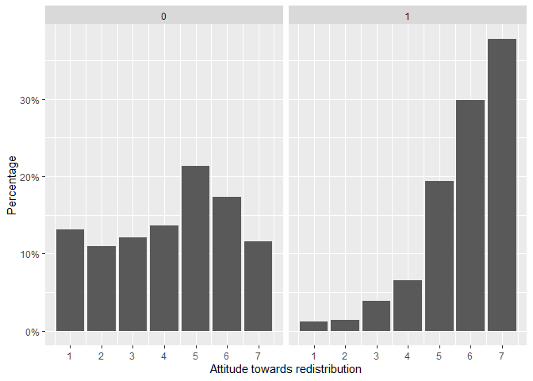

### NL

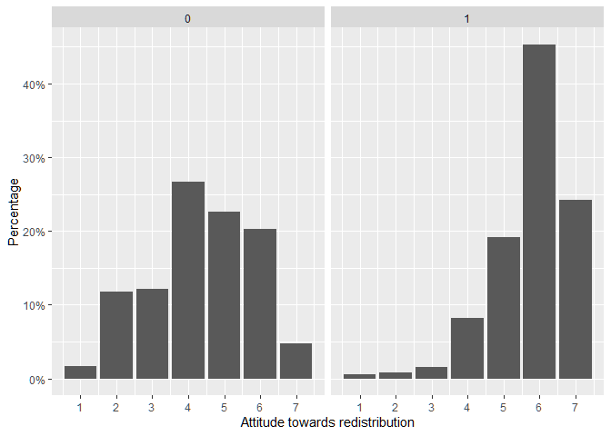

## Regressions

### Without Treatment Control

Table. Linear regression models on preference for redistribution - US & NL (Without Treatment)

M1_US

M2_US

M3_US

M1_NL

M2_NL

M3_NL

Estimates

Estimates

Estimates

Estimates

Estimates

Estimates

(Intercept)

4.17 ***  
(4.08 – 4.26)

5.83 ***  
(5.51 – 6.15)

6.60 ***  
(6.28 – 6.92)

4.37 ***  
(4.28 – 4.46)

5.85 ***  
(5.45 – 6.25)

6.75 ***  
(6.32 – 7.18)

CCA: CCA 1

1.65 ***  
(1.52 – 1.78)

1.10 ***  
(0.96 – 1.23)

1.41 ***  
(1.28 – 1.54)

1.13 ***  
(1.00 – 1.26)

agegroups28-37

-0.05  
(-0.24 – 0.14)

-0.03  
(-0.22 – 0.17)

0.09  
(-0.24 – 0.42)

0.05  
(-0.31 – 0.41)

agegroups38-47

-0.21 **  
(-0.41 – -0.01)

-0.12  
(-0.33 – 0.10)

0.16  
(-0.17 – 0.49)

0.17  
(-0.19 – 0.54)

agegroups48-57

-0.85 ***  
(-1.06 – -0.64)

-0.80 ***  
(-1.02 – -0.58)

0.24  
(-0.07 – 0.55)

0.25  
(-0.09 – 0.59)

Age(in groups): 58+

-0.96 ***  
(-1.15 – -0.78)

-0.88 ***  
(-1.07 – -0.68)

0.29 *  
(-0.00 – 0.58)

0.34 **  
(0.02 – 0.66)

sexMale

0.09  
(-0.03 – 0.21)

0.06  
(-0.07 – 0.18)

0.02  
(-0.11 – 0.15)

0.09  
(-0.06 – 0.24)

raceWhite

-0.06  
(-0.20 – 0.08)

-0.10  
(-0.25 – 0.05)

-0.24 **  
(-0.47 – -0.01)

-0.22 *  
(-0.48 – 0.03)

education: Some college

0.24 **  
(0.02 – 0.46)

0.31 ***  
(0.08 – 0.54)

-0.34 ***  
(-0.57 – -0.11)

-0.44 ***  
(-0.69 – -0.19)

education: College or  
more

0.30 ***  
(0.10 – 0.50)

0.40 ***  
(0.19 – 0.60)

-0.21 ***  
(-0.36 – -0.06)

-0.25 ***  
(-0.42 – -0.09)

working

0.05  
(-0.09 – 0.19)

0.03  
(-0.11 – 0.17)

-0.14 *  
(-0.30 – 0.02)

-0.20 **  
(-0.38 – -0.02)

Political orientation

-0.23 ***  
(-0.25 – -0.20)

-0.30 ***  
(-0.32 – -0.28)

-0.20 ***  
(-0.23 – -0.17)

-0.27 ***  
(-0.30 – -0.24)

hhincome groups: Medium

-0.32 ***  
(-0.51 – -0.14)

-0.44 ***  
(-0.64 – -0.25)

0.05  
(-0.11 – 0.20)

0.05  
(-0.12 – 0.22)

hhincome groups: High

-0.27 **  
(-0.48 – -0.06)

-0.44 ***  
(-0.66 – -0.22)

-0.64 ***  
(-0.97 – -0.31)

-0.81 ***  
(-1.17 – -0.45)

immigrant

0.09  
(-0.13 – 0.32)

0.04  
(-0.20 – 0.28)

0.08  
(-0.18 – 0.34)

0.02  
(-0.26 – 0.30)

marital

0.18 ***  
(0.05 – 0.32)

0.17 **  
(0.03 – 0.31)

-0.12 *  
(-0.26 – 0.02)

-0.12  
(-0.27 – 0.03)

religionNone

-0.20 **  
(-0.37 – -0.03)

-0.04  
(-0.22 – 0.14)

-0.04  
(-0.23 – 0.15)

-0.07  
(-0.28 – 0.14)

religionOther

-0.26 ***  
(-0.44 – -0.07)

-0.18 *  
(-0.38 – 0.01)

-0.17  
(-0.63 – 0.30)

-0.19  
(-0.70 – 0.32)

religionProtestant

-0.40 ***  
(-0.58 – -0.23)

-0.35 ***  
(-0.54 – -0.16)

0.05  
(-0.19 – 0.28)

0.05  
(-0.21 – 0.31)

Observations

2479

2479

2479

1452

1452

1452

R<sup>2</sup> / R<sup>2</sup> adjusted

0.200 / 0.200

0.381 / 0.376

0.313 / 0.308

0.233 / 0.232

0.350 / 0.342

0.213 / 0.203

AIC

9519.647

8920.683

9175.851

4833.907

4626.879

4903.488

- p<0.1 ** p<0.05 *** p<0.01

### With Treatment Control

Table. Linear regression models on preference for redistribution - US & NL (With Treatment)

M1_US

M2_US

M3_US

M1_NL

M2_NL

M3_NL

Estimates

Estimates

Estimates

Estimates

Estimates

Estimates

(Intercept)

4.12 ***  
(4.00 – 4.24)

5.78 ***  
(5.45 – 6.10)

6.52 ***  
(6.19 – 6.85)

4.27 ***  
(4.15 – 4.40)

5.78 ***  
(5.37 – 6.18)

6.64 ***  
(6.20 – 7.07)

CCA: CCA 1

1.65 ***  
(1.52 – 1.78)

1.09 ***  
(0.96 – 1.23)

1.40 ***  
(1.27 – 1.53)

1.12 ***  
(0.99 – 1.25)

treatment: treatment 1

0.19 **  
(0.01 – 0.37)

0.16 *  
(-0.00 – 0.31)

0.16 *  
(-0.00 – 0.33)

0.24 ***  
(0.08 – 0.40)

0.25 ***  
(0.10 – 0.40)

0.32 ***  
(0.15 – 0.48)

treatment: treatment 2

0.04  
(-0.14 – 0.22)

0.04  
(-0.11 – 0.20)

0.10  
(-0.07 – 0.27)

0.05  
(-0.11 – 0.21)

0.08  
(-0.07 – 0.22)

0.12  
(-0.04 – 0.29)

treatment: treatment 3

0.04  
(-0.14 – 0.22)

0.07  
(-0.09 – 0.22)

0.15 *  
(-0.02 – 0.31)

agegroups28-37

-0.05  
(-0.23 – 0.14)

-0.02  
(-0.22 – 0.18)

0.09  
(-0.24 – 0.42)

0.05  
(-0.32 – 0.41)

agegroups38-47

-0.21 **  
(-0.41 – -0.01)

-0.11  
(-0.33 – 0.10)

0.16  
(-0.17 – 0.49)

0.17  
(-0.19 – 0.53)

agegroups48-57

-0.85 ***  
(-1.06 – -0.64)

-0.79 ***  
(-1.02 – -0.57)

0.23  
(-0.08 – 0.54)

0.23  
(-0.11 – 0.57)

Age(in groups): 58+

-0.96 ***  
(-1.15 – -0.78)

-0.87 ***  
(-1.06 – -0.68)

0.28 *  
(-0.01 – 0.57)

0.33 **  
(0.01 – 0.65)

sexMale

0.09  
(-0.03 – 0.21)

0.06  
(-0.06 – 0.18)

0.02  
(-0.11 – 0.15)

0.09  
(-0.06 – 0.24)

raceWhite

-0.06  
(-0.20 – 0.08)

-0.11  
(-0.25 – 0.04)

-0.23 *  
(-0.46 – 0.00)

-0.21 *  
(-0.47 – 0.04)

education: Some college

0.24 **  
(0.02 – 0.45)

0.31 ***  
(0.08 – 0.54)

-0.33 ***  
(-0.55 – -0.10)

-0.43 ***  
(-0.68 – -0.18)

education: College or  
more

0.30 ***  
(0.10 – 0.49)

0.39 ***  
(0.19 – 0.60)

-0.21 ***  
(-0.36 – -0.06)

-0.25 ***  
(-0.41 – -0.09)

working

0.05  
(-0.09 – 0.19)

0.03  
(-0.12 – 0.17)

-0.14 *  
(-0.30 – 0.02)

-0.20 **  
(-0.38 – -0.02)

Political orientation

-0.22 ***  
(-0.25 – -0.20)

-0.30 ***  
(-0.32 – -0.28)

-0.21 ***  
(-0.24 – -0.17)

-0.27 ***  
(-0.30 – -0.24)

hhincome groups: Medium

-0.32 ***  
(-0.50 – -0.13)

-0.44 ***  
(-0.63 – -0.24)

0.04  
(-0.12 – 0.19)

0.04  
(-0.13 – 0.20)

hhincome groups: High

-0.26 **  
(-0.47 – -0.05)

-0.43 ***  
(-0.65 – -0.21)

-0.63 ***  
(-0.96 – -0.31)

-0.80 ***  
(-1.16 – -0.44)

immigrant

0.09  
(-0.14 – 0.31)

0.03  
(-0.20 – 0.27)

0.08  
(-0.18 – 0.33)

0.02  
(-0.27 – 0.30)

marital

0.18 ***  
(0.05 – 0.32)

0.17 **  
(0.03 – 0.31)

-0.12 *  
(-0.26 – 0.01)

-0.12  
(-0.27 – 0.03)

religionNone

-0.20 **  
(-0.37 – -0.03)

-0.04  
(-0.22 – 0.13)

-0.06  
(-0.25 – 0.13)

-0.09  
(-0.30 – 0.12)

religionOther

-0.26 ***  
(-0.45 – -0.07)

-0.19 *  
(-0.38 – 0.01)

-0.21  
(-0.67 – 0.25)

-0.24  
(-0.75 – 0.26)

religionProtestant

-0.41 ***  
(-0.59 – -0.23)

-0.36 ***  
(-0.55 – -0.17)

0.04  
(-0.20 – 0.27)

0.04  
(-0.22 – 0.30)

Observations

2479

2479

2479

1452

1452

1452

R<sup>2</sup> / R<sup>2</sup> adjusted

0.202 / 0.200

0.381 / 0.376

0.314 / 0.309

0.238 / 0.236

0.355 / 0.346

0.221 / 0.210

AIC

9521.148

8922.897

9176.689

4828.267

4619.346

4893.028

- p<0.1 ** p<0.05 *** p<0.01

# Robustness check (Treatment groups)

## T-tests

### US

```
## treatment <categorical>
## # total N=2479 valid N=2479 mean=1.20 sd=1.17
##
## Value |   N | Raw % | Valid % | Cum. %
## --------------------------------------
##     0 | 994 | 40.10 |   40.10 |  40.10
##     1 | 491 | 19.81 |   19.81 |  59.90
##     2 | 495 | 19.97 |   19.97 |  79.87
##     3 | 499 | 20.13 |   20.13 | 100.00
##  <NA> |   0 |  0.00 |    <NA> |   <NA>
```

| group1 | group2 | variable | dif_mean | pvalues |
| --- | --- | --- | --- | --- |
| Control | Wealth inequality | perc_income | -0.4110000 | 0.00000008262007 |
| Control | Wealth inequality | perc_wealth | -0.3731452 | 0.00000109915160 |
| Control | Wealth inequality | ib_weafam | -0.1892097 | 0.00033525717996 |
| Control | Wealth inequality | ib_edupar | -0.1904355 | 0.00015646232749 |
| Control | Racial discrimination | perc_black | -0.4354900 | 0.00000100477916 |
| Control | Coronavirus | perc_income | -0.2420139 | 0.00149521479931 |
| Control | Coronavirus | perc_poor | -0.2462962 | 0.00045901177092 |
| Wealth inequality | Racial discrimination | perc_income | 0.3147410 | 0.00031351767614 |
| Wealth inequality | Racial discrimination | perc_wealth | 0.3084838 | 0.00040196697129 |
| Wealth inequality | Racial discrimination | perc_black | -0.3976513 | 0.00018969106040 |

### NL

```
## treatment <categorical>
## # total N=1452 valid N=1452 mean=1.00 sd=0.82
##
## Value |   N | Raw % | Valid % | Cum. %
## --------------------------------------
##     0 | 484 | 33.33 |   33.33 |  33.33
##     1 | 480 | 33.06 |   33.06 |  66.39
##     2 | 488 | 33.61 |   33.61 | 100.00
##  <NA> |   0 |  0.00 |    <NA> |   <NA>
```

| group1 | group2 | variable | dif_mean | pvalues |
| --- | --- | --- | --- | --- |
| Control | Wealth inequality | perc_income | -0.4118037 | 0.0007105831 |
| Control | Wealth inequality | perc_wealth | -0.3895225 | 0.0012748264 |
| Control | Racial discrimination | perc_black | -0.4206897 | 0.0004562401 |

## EGA (Treatment group 1 - Wealth inequality)

### US

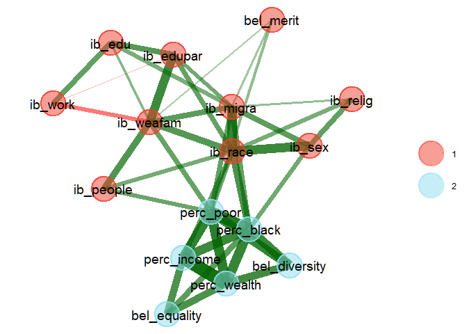

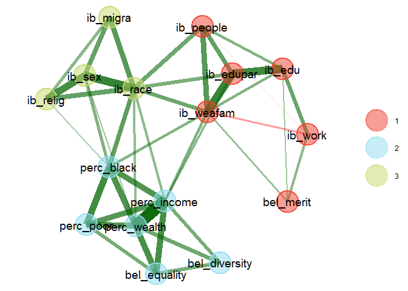

### NL

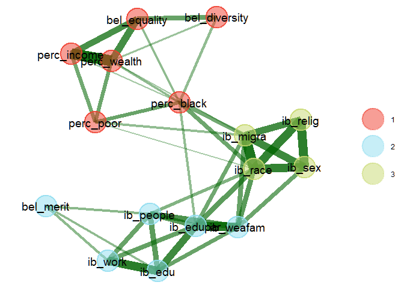

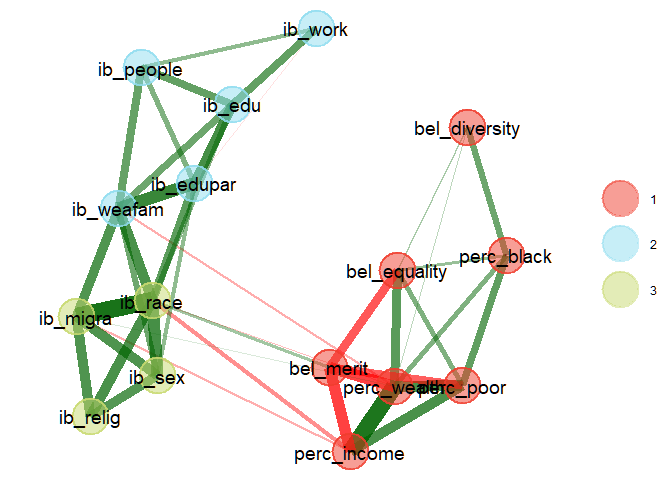